# ICP-Based Euclidean Distance Measurement for Tunnel Deformation Analysis

Source: Dr. Mahamadou CAMARA, PhD – Geomatics Engineering mahamadoucamaramoc@outlook.com

## 1. Introduction

This document presents the mathematical formulation of the Iterative Closest Point (ICP) concept and Euclidean distance–based deformation measurement, as implemented in the Python workflow for shield tunnel deformation analysis using mobile laser scanning point cloud data. In this study, geomatics engineering methods combined with mathematical modeling are applied, including mobile laser scanning (LiDAR) point cloud processing, ICP-based point correspondence, Euclidean distance measurement for three-dimensional displacement analysis, and geometric modeling (ellipse fitting and ovality assessment), to accurately quantify tunnel deformation.

## 2. Point Cloud Representation

Let the tunnel point clouds acquired at two different epochs be defined as: P₁ = { pᵢ = (xᵢ¹, yᵢ¹, zᵢ¹) | i = 1, …, N } P₂ = { qⱼ = (xⱼ², yⱼ², zⱼ²) | j = 1, …, M } where P₁ and P₂ represent the tunnel surface at times t₁ and t₂, respectively.

## 4. Distance Threshold and Outlier Rejection

A tolerance threshold τ is introduced to discard unreliable correspondences: dᵢ ≤ τ Points exceeding this threshold are considered outliers and removed, improving robustness against noise and occlusions.

## 5. Euclidean Distance Deformation Equation

Once the closest point correspondence is established, the deformation magnitude dᵢ for each point is computed as:

dᵢ = √[(xᵢ² − xᵢ¹)² + (yᵢ² − yᵢ¹)² + (zᵢ² − zᵢ¹)²]

This Euclidean distance represents the true three-dimensional displacement of the tunnel lining.

## 6. Relevance to Tunnel Deformation Monitoring

### The ICP-based correspondence and Euclidean distance framework enables millimeter-level deformation detection and is well suited for shield tunnel monitoring using high-density mobile laser scanning data.

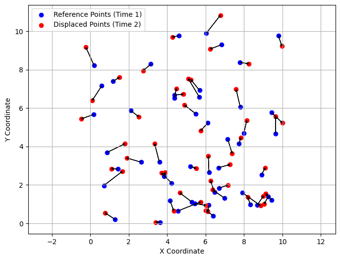

```python
import numpy as np
import matplotlib.pyplot as plt

# Generate synthetic point cloud data (Scene at Time 1)
np.random.seed(0)
n_points = 50
x_time1 = np.random.rand(n_points) * 10  # Random x-coordinates
y_time1 = np.random.rand(n_points) * 10  # Random y-coordinates

# Generate point cloud data at Time 2 (shifted version of Time 1 data)
shift = np.random.normal(scale=0.5, size=(n_points, 2))  # Random shifts in x and y
x_time2 = x_time1 + shift[:, 0]
y_time2 = y_time1 + shift[:, 1]

# Combine x and y coordinates into point clouds
point_cloud_time1 = np.vstack((x_time1, y_time1)).T
point_cloud_time2 = np.vstack((x_time2, y_time2)).T

# Plot the two point clouds
plt.figure(figsize=(8, 6))
plt.scatter(x_time1, y_time1, color='blue', label='Reference Points (Time 1)', marker='o')
plt.scatter(x_time2, y_time2, color='red', label='Displaced Points (Time 2)', marker='o')  # Changed marker to 'o'

# Draw arrows to show the displacement of each point
for i in range(n_points):
    plt.arrow(x_time1[i], y_time1[i], x_time2[i] - x_time1[i], y_time2[i] - y_time1[i],
                  head_width=0.1, head_length=0.1, fc='black', ec='black', length_includes_head=True)

# Plot settings
plt.xlabel('X Coordinate')
plt.ylabel('Y Coordinate')
# plt.title('Comparison of Point Clouds at Two Different Times')
plt.legend()
plt.grid(True)
plt.axis('equal')  # To ensure the aspect ratio is equal
plt.show()
```

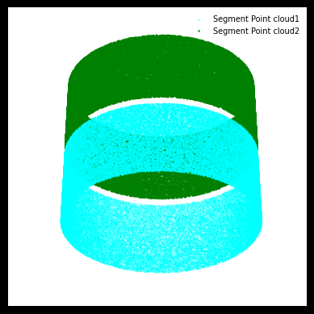

```python
import numpy as np
import matplotlib.pyplot as plt
from mpl_toolkits.mplot3d import Axes3D

# Parameters
num_points = 90000  # Number of points in each segment
radius = 25          # Radius of the tunnel
height = 50         # Height of each tunnel segment
y_offset = 5        # Offset between the two tunnel segments

# Generate points for the top tunnel segment (cyan)
theta1 = np.random.uniform(0, 2 * np.pi, num_points)
y1 = np.random.uniform(0, height, num_points)
x1 = radius * np.cos(theta1)
z1 = radius * np.sin(theta1)

# Generate points for the bottom tunnel segment (yellow)
theta2 = np.random.uniform(0, 2 * np.pi, num_points)
y2 = np.random.uniform(0, height, num_points) - height - y_offset  # Offset in Y-axis
x2 = radius * np.cos(theta2)
z2 = radius * np.sin(theta2)

# Create a 3D plot with a black background
fig = plt.figure(facecolor='black')
ax = fig.add_subplot(111, projection='3d', facecolor='white')

# Plot the top tunnel segment (cyan)
ax.scatter(x1, y1, z1, color='cyan', s=0.1, label='Segment Point cloud1')

# Plot the bottom tunnel segment (yellow)
ax.scatter(x2, y2, z2, color='green', s=0.5, label='Segment Point cloud2')

# Set plot limits and view angle
ax.set_xlim(-radius, radius)
ax.set_ylim(-height - y_offset, height)
ax.set_zlim(-radius, radius)
ax.view_init(elev=45, azim=90)  # Set view to look down the Y-axis (cross-section view)
ax.axis('off')  # Hide axes

# Add a legend for the color-coded segments
plt.legend(loc='upper right', fontsize=7, frameon=False, labelcolor='black')

# Display the plot
plt.show()
```

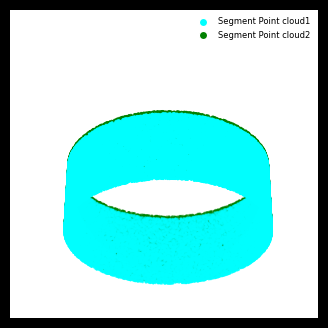

```python
import numpy as np
import matplotlib.pyplot as plt
from mpl_toolkits.mplot3d import Axes3D
from sklearn.neighbors import NearestNeighbors
from matplotlib.lines import Line2D

# -------------------------------------------------
# ICP algorithm (translation only - simplified)
# -------------------------------------------------
def icp(A, B, max_iterations=50, tolerance=1e-5):
    src = np.copy(A)
    prev_error = 0

    for i in range(max_iterations):
        nbrs = NearestNeighbors(n_neighbors=1).fit(B)
        distances, indices = nbrs.kneighbors(src)

        T = np.mean(B[indices[:, 0]] - src, axis=0)
        src += T

        mean_error = np.mean(distances)
        if abs(prev_error - mean_error) < tolerance:
            break
        prev_error = mean_error

    return src
# -------------------------------------------------
# Parameters
# -------------------------------------------------
num_points = 60000
radius = 2
height = 40
y_offset = 10

# -------------------------------------------------
# Generate top tunnel segment (cyan)
# -------------------------------------------------
theta1 = np.random.uniform(0, 2 * np.pi, num_points)
y1 = np.random.uniform(0, height, num_points)
x1 = radius * np.cos(theta1)
z1 = radius * np.sin(theta1)

top_segment = np.vstack((x1, y1, z1)).T

# -------------------------------------------------
# Generate bottom tunnel segment (green, shifted)
# -------------------------------------------------
theta2 = np.random.uniform(0, 2 * np.pi, num_points)
y2 = np.random.uniform(0, height, num_points) - height - y_offset
x2 = radius * np.cos(theta2)
z2 = radius * np.sin(theta2)

bottom_segment = np.vstack((x2, y2, z2)).T

# -------------------------------------------------
# Apply ICP
# -------------------------------------------------
aligned_bottom_segment = icp(bottom_segment, top_segment)

# -------------------------------------------------
# 3D Plot
# -------------------------------------------------
fig = plt.figure(figsize=(6, 4), facecolor='black')
ax = fig.add_subplot(111, projection='3d', facecolor='white')

ax.scatter(
    top_segment[:, 0],
    top_segment[:, 1],
    top_segment[:, 2],
    color='cyan',
    s=1
)

ax.scatter(
    aligned_bottom_segment[:, 0],
    aligned_bottom_segment[:, 1],
    aligned_bottom_segment[:, 2],
    color='green',
    s=1
)

# -------------------------------------------------
# View & limits (cross-section view)
# -------------------------------------------------
ax.set_xlim(-radius, radius)
ax.set_ylim(-height - y_offset, height)
ax.set_zlim(-radius, radius)

ax.view_init(elev=45, azim=90)
ax.axis('off')

# -------------------------------------------------
# Robust legend (proxy artists)
# -------------------------------------------------
legend_elements = [
    Line2D([0], [0], marker='o', color='w',
           label='Segment Point cloud1',
           markerfacecolor='cyan', markersize=6),

    Line2D([0], [0], marker='o', color='w',
           label='Segment Point cloud2',
           markerfacecolor='green', markersize=6)
]

ax.legend(
    handles=legend_elements,
    loc='upper right',
    fontsize=6,
    frameon=False
)

# -------------------------------------------------
# Show
# -------------------------------------------------
plt.show()
```